# Stocks and Dividends

Data Computing

Computing project

# Stocks and Dividends

Many companies are publicly traded. This means that the company issues stock certificates which can be bought and sold on an exchange. Investors buy stock certificates mainly because they can sell them in the future, perhaps making a profit, and because companies pay dividends, a share of the company’s profit, to each shareholder.

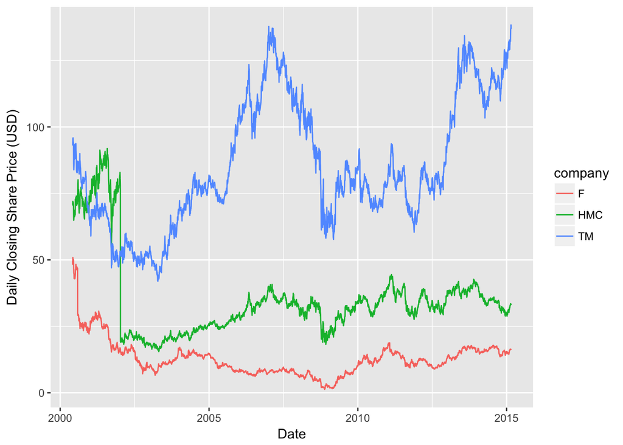

Figure 1. Stock prices for Ford, Honda, and Toyota

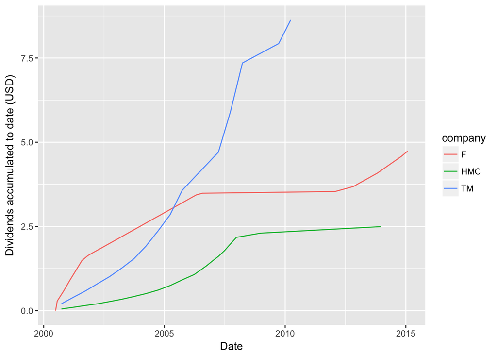

Figure 2. Accumulated dividends (per share) paid by Ford, Honda, and Toyota

Figures 1 and 2 show the scale of price fluctuations and of accumulated dividends.

## Task

Compare the income (or loss) that comes from buying and selling a stock certificate to the income that comes from dividends over the same period. Answer these questions:

- Which source of income is bigger?
- Is there any correlation between the income from dividends and the income (or loss) from buying and selling?

## Getting Price Data

```r
companies <- c("F", "TM", "HMC")
Prices <-
  read_stock_prices(companies, what="daily",
                  start_year=2000, end_year=2015)
```

- Choose a few companies of interest to you. You can find stock company symbols at `finance.yahoo.com`. (Suggestion: pick a sector of the economy, e.g. energy, high-tech, consumer products, etc. and use companies from that sector.)
- Plot out the “closing price” (`Close`) versus `date` to get a graphic like Figure 1.

## Buy/Sell Profit

The dollar amount is profit per share.

> *Hints*: (1) What kind of join should you use so that you get only those cases that match one of the dates in the `Actions` table? (2) Wide-vs-long techniques will be useful. (See *Data Computing* Chapter 11.)

From the data table with buy and sell prices, calculate the dollar amount of profit (or loss) and the percentage change, as shown here.

`company profit percent`  
`1 F 7.67 98.00`  
`2 HMC 0.24 0.82`  
`3 TM 19.10 18.00`  
Profit and percentage change in price.

## Indexing Prices

Since stock prices vary markedly from one company to another, a common practice is to “index” the price to a particular date as in Figure 3. (Question: In the graph, roughly which date was used for the reference?)

- Pick a single date of your choice and extract the stock price information for each company on that date. In the result, there should be one case for each company. Select just the `date`, `company`, and `close` variables, renaming `close` as `standard`. Call the resulting data frame `Reference`.

```r
ref_date <- ymd("2005-01-03")
Reference <-
  Prices %>%
  filter(date==ref_date) %>%
  select(company, standard=close)
```

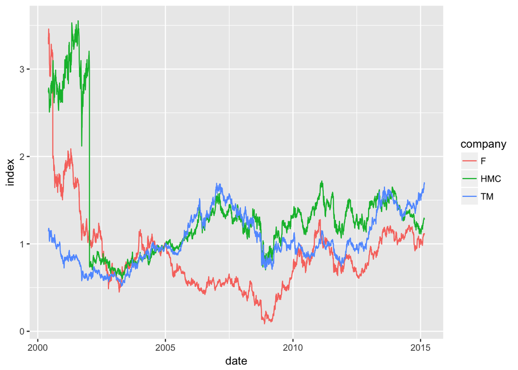

Figure 3. Indexed stock prices for Ford, Honda, and Toyota

- You now need to combine the `Reference` with each day’s price data for that company. You’ll find the standardized price on each day by creating a new variable which is the ratio of the day-to-day price (use `Close`) to the `standard` for that company. Before you can do this, you’ll need to combine the `Prices` and `Reference` data tables. You’ll use a *join* verb to do this. In order to check your results, sketch out what you think the result *should* be before you do the join.

## Dividends

You can read in dividend data like this:

```r
Dividends <-
  read_stock_prices(companies, what="dividends")
```

Once you have the dividend data, extract out the dividends for all dates between your buy and sell dates. (Hint: Join `Dividends` to `Actions` using `company` to match.)

- The dividend amount is actually a rate: the dividend paid (in dollars) divided by the stock price. Find the dollar amount of each dividend payment for one *share* of stock rather than one *dollar* of stock. This involves multiplying the dividend rate by the stock price on that date.

`company total_dividend`  
`1 F 1.750`  
`2 HMC 1.885`  
`3 TM 6.259`  
Table 1. Dividends (in dollars per share) paid out by each company over the interval 2005 through 2014.

- Find the total amount of dividends for each company during the period of interest. Compare this amount to the profit (or loss) from buying and selling the stock certificates. For the car companies, the result for the period 2005-01-01 though 2014-12-31 is shown in Table 1 .